# Краткое введение в мир линейной алгебры. Часть 2

## Вы сможете

- Объяснить что такое матрицы и какие бывают их основные разновидности
- Выполнить базовые операции с матрицами с использованием функций R
- Применить в среде R методы линейной алгебры для решения простейших задач

## Level 1: Зоопарк матричных объектов

## Матричные объекты

- Есть много типов объектов, для которых такое выражение оказывается наиболее естественным (изображения, описания многомерных объектов и т.д.)
- В матрицах, как и в обычных числах, скрыта информация, которую можно извлекать и преобразовывать по определенным правилам

## Структура матриц

\[\begin{pmatrix} a_{11} & a_{12} & \cdots & a_{1c} \\ a_{21} & a_{22} & \cdots & a_{2c} \\ \vdots & \vdots & \ddots & \vdots \\ a_{r1} & a_{r2} & \cdots & a_{rc} \end{pmatrix} \]

Размер (порядок) матрицы \(r \times c\)

## Разновидности матриц

\[ \textbf {a} = \begin{pmatrix} 1 & 2 & 3 \end{pmatrix} \] Вектор-строка (Row matrix)

\[ \textbf {b} = \begin{pmatrix} 1 \\ 4 \\ 7 \\ 10 \end{pmatrix} \] Вектор-столбец (column matrix)

## Разновидности матриц

\[ \textbf {C} = \begin{pmatrix} 1 & 2 & 3 \\ 4 & 5 & 6 \\ 7 & 8 & 9 \\ 10 & 11 & 12 \end{pmatrix} \]

\[ \textbf {D} = \begin{pmatrix} 1 & 2 & 3 \\ 4 & 5 & 6 \end{pmatrix} \]

> Прямоугольные матрицы (rectangular matrices)

> В таком виде обычно представляются исходные данные при многомерном анализе.

В такой матрице столбцы - признаки (p), а строки - объекты (n).

Лучше, когда n > p, то есть когда объектов больше, чем признаков.

## Квадратные матрицы (square matrices)

Это наиболее “операбельные” матрицы

\[ \textbf {E} = \begin{pmatrix} 1 & 2 & 3 \\ 4 & 5 & 6 \\ 7 & 8 & 9 \end{pmatrix} \]

Диагональные матрицы (diagonal matrix)

\[ \textbf {F} = \begin{pmatrix} 1 & 0 & 0 & 0 \\ 0 & 5 & 0 & 0 \\ 0 & 0 & 9 & 0 \\ 0 & 0 & 0 & 1 \end{pmatrix} \]

## Квадратные матрицы (square matrices)

Треугольные матрицы (triangular matrices) \[ \textbf {H} = \begin{pmatrix} 1 & 2 & 3 & 4 \\ 0 & 5 & 6 & 7 \\ 0 & 0 & 9 & 10 \\ 0 & 0 & 0 & 1 \end{pmatrix} \]

или

\[ \textbf {H} = \begin{pmatrix} 1 & 0 & 0 & 0 \\ 3 & 5 & 0 & 0 \\ 4 & 7 & 9 & 0 \\ 5 & 8 & 10 & 11 \end{pmatrix} \]

## Квадратные матрицы (square matrices)

Единичная матрица (identity matrix)

\[ \textbf {I} = \begin{pmatrix} 1 & 0 & 0 & 0 \\ 0 & 1 & 0 & 0 \\ 0 & 0 & 1 & 0 \\ 0 & 0 & 0 & 1 \end{pmatrix} \]

Единичная матрица (обозначение \(\textbf{I}\)) занимают особое место в матричной алгебре.  
Она выполняет ту же роль, которую выполняет единица в обычной алгебре.

## Матрицы ассоциации

Изначально результаты исследования имеют вид исходной матрицы (обычно прямоугольной)

\[ \textbf{Y} = [n_{objects} \times p_{descriptors}] \]

Информация из этой матрицы конденсируется в двух других матрицах

Q анализ

\[ \textbf{A}_{nn} = [n_{objects} \times n_{objects}] \]

R анализ

\[ \textbf{A}_{pp} = [p_{descriptors} \times p_{descriptors}] \]

## Матрицы ассоциации

Это симметричные квадратные матрицы

\[ \textbf{A}_{pp} = \begin{pmatrix} a_{11} & a_{12} & \cdots & a_{1p} \\ a_{21} & a_{22} & \cdots & a_{2p} \\ \vdots & \vdots & \ddots & \vdots \\ a_{p1} & a_{p2} & \cdots & a_{pp} \end{pmatrix} \]

В этой матрице \(a_{ij} = a_{ji}\)

Большинство многомерных методов имеет дело именно с такими матрицами

## Особенность квадратных матриц

Для квадратных матриц могут быть найдены (но не обязательно существуют) некоторые важные для линейной алгебры показатели: *определитель*, *инверсия*, *собственные значения* и *собственные векторы*

## Задание

Создайте с помощью R следующие матрицы

```
##      [,1] [,2] [,3]
## [1,]    1    5    9
## [2,]    2    6   10
## [3,]    3    7   11
## [4,]    4    8   12
```

```
##      [,1] [,2] [,3] [,4] [,5]
## [1,]    1    0    0    0    0
## [2,]    0    1    0    0    0
## [3,]    0    0    1    0    0
## [4,]    0    0    0    1    0
## [5,]    0    0    0    0    1
```

## Level 2: Простейшие операции с матричными объектами

## Транспонирование матриц

```r
A <- matrix(1:12, ncol = 3)
A
```

```
##      [,1] [,2] [,3]
## [1,]    1    5    9
## [2,]    2    6   10
## [3,]    3    7   11
## [4,]    4    8   12
```

Транспонированная матрица \(\textbf{B} = \textbf{A}'\) синонимичная запись \(\textbf{B} = \textbf{A}^{T}\)

```r
B <- t(A)
B
```

```
##      [,1] [,2] [,3] [,4]
## [1,]    1    2    3    4
## [2,]    5    6    7    8
## [3,]    9   10   11   12
```

## Сложение матриц

```r
A + 4
```

```
##      [,1] [,2] [,3]
## [1,]    5    9   13
## [2,]    6   10   14
## [3,]    7   11   15
## [4,]    8   12   16
```

```r
A + A
```

```
##      [,1] [,2] [,3]
## [1,]    2   10   18
## [2,]    4   12   20
## [3,]    6   14   22
## [4,]    8   16   24
```

Но! Нельзя складывать матрицы разных размеров

```r
A + B
```

[output not shown]

## Простое умножение

Умножение на число

```r
A * 4
```

```
##      [,1] [,2] [,3]
## [1,]    4   20   36
## [2,]    8   24   40
## [3,]   12   28   44
## [4,]   16   32   48
```

Простое умножение матрицы на вектор возможно только если число элементов в векторе равно числу строк в матрице

```r
A * c(10, 11, 12, 13)
```

```
##      [,1] [,2] [,3]
## [1,]   10   50   90
## [2,]   22   66  110
## [3,]   36   84  132
## [4,]   52  104  156
```

Все элементы первой строки матрицы умножаются на первый элемент вектора, все элементы второй строки на второй элемент вектора и т.д.

## Level 3: Векторы и их геометрическая интерпретация

## Интерпретация вектора

Вектор – это последовательность чисел: \((x_1, x_2, ..., x_n)\).

Геометрической интерпретацией вектора является направленный отрезок в n-мерном пространстве с началом в точке \((0, 0 .... 0)\).

Если в векторе всего два числа, то это направленный отрезок на плоскости.

Пример: `vec = (1, 5)`

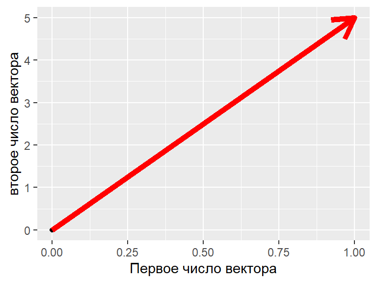

```r
vec <- data.frame(x = c(0, 1), y = c(0, 5))
ggplot(vec, aes(x, y)) +
  geom_point() +
  geom_path(arrow = arrow(), size = 2, color = "red") +
  labs(x="Первое число вектора", y ="второе число вектора")
```

## Длина вектора

Длина вектора, или норма вектора

\[ ||\textbf{b}|| = \sqrt{b_1^2 + b_2^2 + \dots + b_n^2} \]

Длина вектора

```r
Vec <- 1:5

sqrt(sum(Vec^2))
```

```
## [1] 7.42
```

```r
norm(t(Vec), type = "F") #Аналогчное решение
```

```
## [1] 7.42
```

## Скалярное произведение векторов

Допустимо только для векторов одинаковой размерности

\[ \textbf{a} \cdot \textbf{b} = \begin{pmatrix} a_1 \\ a_3 \\ a_4 \\ a_5 \\ a_6 \\ a_7 \end{pmatrix} \times \begin{pmatrix} b_1 & b_3 & b_4 & b_5 & b_6 & b_7 \end{pmatrix} = a_1b_1 + a_2b_2 + ... + a_7b_7 = x \]

Это базовая операция для истинного матричного умножения.

Результат этой операции - число (скаляр)

## Как это работает?

### Бытовой пример

В доме есть следующие электроприборы.

| Электроприбор | Количество | Мощность (Вт) |
| --- | --- | --- |
| Чайник | 2 шт | 1200 |
| Обогреватели | 3 шт. | 1300 |
| Осушитель | 1 шт. | 1100 |
| Стиральная машина | 1 шт. | 1500 |
| Фен | 2 шт. | 800 |

Вопрос: Какова будет суммарная мощность всех электроприборов, если их включить одновременно?

## Решение

```r
a <- c(2, 3, 1, 1, 2)
b <- c(1200, 1300, 1100, 1500, 800)

a %*% b
```

```
##       [,1]
## [1,] 10500
```

## Геометрическая интерпретация скалярного произведения векторов

Скалярное произведение равно произведению длин векторов на \(cos\) угла между ними

\[ \textbf{a} \cdot \textbf{b} = ||\textbf{a}|| \times ||\textbf{b}|| \times \cos(\alpha) \]

Если угол между векторами равен 90 градусов, то такие векторы называются ортогональными.

У таких векторов скалярное произведение \(\textbf{a} \cdot \textbf{b} = 0\)

## Задание

Выясните, являются ли ортогональными следующие векторы?

```r
a <- c(0, 1)
b <- c(1, 0)
c <- c(1, 1)
d <- c(1, -1)
```

## Решение

Аналитическое решение

```r
(a) %*% (b) #Ортогональны
```

```
##      [,1]
## [1,]    0
```

```r
(c) %*% (a) #Неортогональны
```

```
##      [,1]
## [1,]    1
```

```r
(c) %*% (b) #Неортогональны
```

```
##      [,1]
## [1,]    1
```

```r
(d) %*% (c) #Ортогональны
```

```
##      [,1]
## [1,]    0
```

```r
(c) %*% (a) #неортогональны
```

```
##      [,1]
## [1,]    1
```

```r
(b) %*% (d) #неортогональны
```

```
##      [,1]
## [1,]    1
```

Геометрическое решение

[figure not shown]

## Угол между векторами

Пусть, векторы отражают признаки объектов.  
Что характеризует угол между векторами?

```
##     Object1 Object2
## Tr1     0.5     0.5
## Tr2     0.0     3.0
```

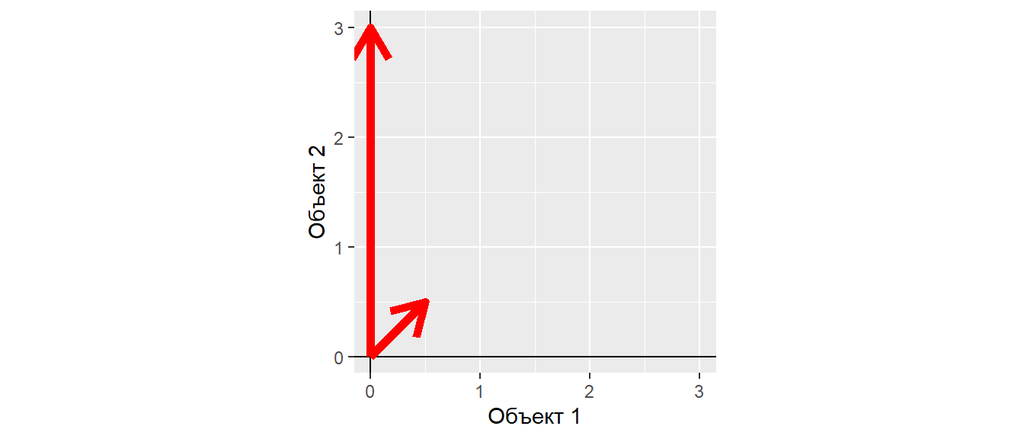

## Угол между векторами

### Длина векторов

```r
norm(t(Dat[ ,1 ]), type = "F") #Длина вектора Tr1
```

```
## [1] 0.707
```

```r
norm(t(Dat[ , 2]), type = "F") #Длина вектора Tr2
```

```
## [1] 3
```

## Угол между веторами

Если

\[ \textbf{a} \cdot \textbf{b} = ||\textbf{a}|| \times ||\textbf{b}|| \times \cos(\alpha) \]

то

\[ \cos(\alpha) = \frac{\textbf{a} \cdot \textbf{b}} {||\textbf{a}|| \times ||\textbf{b}||} \]

```r
cos_a <- (Dat[, 1] %*% Dat[, 2])/(norm(t(Dat[, 1]), type = "F") *
                                    norm(t(Dat[, 2]), type = "F"))

cos_a
```

```
##       [,1]
## [1,] 0.707
```

Угол между векторами - мера сонаправленности векторов…

Вопрос: С помощью какого показателя мы уже умеем оценивать степень взаимосвязи двух сопряженных рядов данных (двух n-мерных векторов)?

- Корреляция! Косинус угла между двумя векторами - мера их корреляции.

## Нормализованные векторы

Для многомерных методов важны взаимоотношения векторов, а не их истинные длины.

Для приведения векторов к соизмеримости проводят их *нормализацию*.

\[ \textbf{c} = \frac{\textbf{b}} {||\textbf{b}||} \]

## Задание

Найдите нормализованный вектор для следующего вектора и определите его длину

```r
Vec <- 1:5
Vec
```

```
## [1] 1 2 3 4 5
```

## Решение

```r
normalized_Vec <- Vec/norm(t(Vec), type = "F")
normalized_Vec
```

```
## [1] 0.135 0.270 0.405 0.539 0.674
```

Длина нормализованного вектора

```r
norm(t(normalized_Vec), type = "F")
```

```
## [1] 1
```

- Длина нормализованного вектора равна 1. Это важное свойство для многомерных методов.

## Нормализованные векторы

Исходные данные

```
##     Object1 Object2
## Tr1     0.5     0.5
## Tr2     0.0     3.0
```

Нормализованные данные

```
##     Object1 Object2
## Tr1   0.707   0.707
## Tr2   0.000   1.000
```

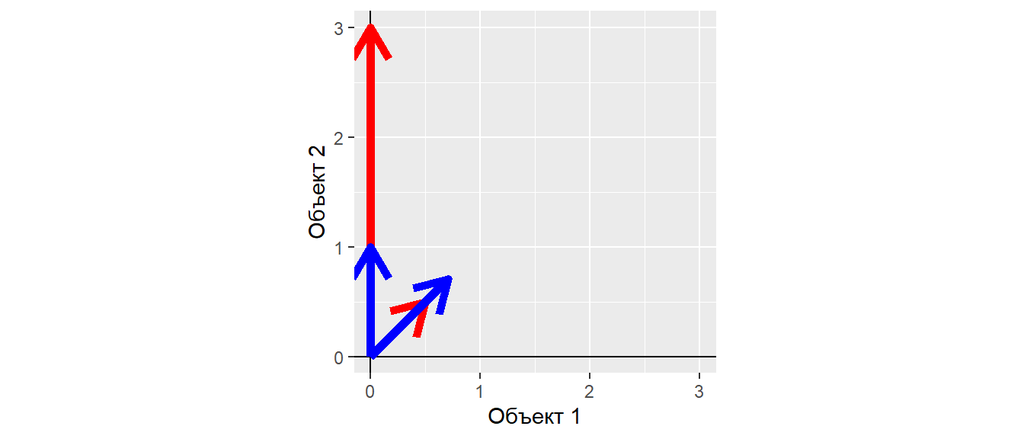

Характер взаимосвязи между нормализованными векторами такой же, как и у исходных векторов.

После нормализации, можно пренебречь разницами длин векторов.

## Level 4: Операции с матрицами

## Матричное умножение матрицы на вектор

\[ \mathbf{A} \times \mathbf{a} \]

Умножать можно только в том случае, если число столбцов в матрице равно количеству чисел в векторе.

Пусть, есть матрица \(\mathbf{A}\)

```
##      [,1] [,2] [,3]
## [1,]    1    5    9
## [2,]    2    6   10
## [3,]    3    7   11
## [4,]    4    8   12
```

```r
A %*% c(10, 10, 10)
```

```
##      [,1]
## [1,]  150
## [2,]  180
## [3,]  210
## [4,]  240
```

- Первое число итогового вектора - скалярное произведение первой строки \(\mathbf{A}\) на вектор \(\mathbf{a}\)
- Второе число - скалярное произведение второй строки \(\mathbf{A}\) на вектор \(\mathbf{a}\)  
  и т.д.

Но! если поменять местами множители, то будет ошибка

```r
c(10, 10, 10) %*% A
```

```
## Error in c(10, 10, 10) %*% A: неподобные аргументы
```

## Матричное умножение вектора на матрицу

\[ \mathbf{a} \times \mathbf{A} \]

Умножать можно только в том случае, если количество чисел в векторе равно количеству строк в матрице.

```r
c(10, 10, 10, 10) %*% A
```

```
##      [,1] [,2] [,3]
## [1,]  100  260  420
```

Но! если поменять местами множители, то будет ошибка

```r
A %*% c(10, 10, 10, 10)
```

```
## Error in A %*% c(10, 10, 10, 10): неподобные аргументы
```

## Умножение матриц

Умножать можно только в том случае, если число колонок в первой матрице равно числу строк второй матрицы: \(\mathbf{A} \times \mathbf{B}\)

Пусть, есть матрица \(\mathbf{A}\)

```
##      [,1] [,2] [,3]
## [1,]    1    5    9
## [2,]    2    6   10
## [3,]    3    7   11
## [4,]    4    8   12
```

и матрица \(\mathbf{B}\)

```
##      [,1] [,2] [,3] [,4]
## [1,]    1    2    3    4
## [2,]    5    6    7    8
## [3,]    9   10   11   12
```

```r
A %*% B
```

```
##      [,1] [,2] [,3] [,4]
## [1,]  107  122  137  152
## [2,]  122  140  158  176
## [3,]  137  158  179  200
## [4,]  152  176  200  224
```

НО! Нельзя произвести такое умножение

```r
A %*% A
```

```
## Error in A %*% A: неподобные аргументы
```

## Схема умножения матриц

\[ \begin{pmatrix} A & B \\ C & D \\ \end{pmatrix} \times \begin{pmatrix} E & F \\ G & H\\ \end{pmatrix} = \begin{pmatrix} (A \cdot E + B \cdot G) & (A \cdot F + B \cdot H ) \\ (C \cdot E + D \cdot G) & (C \cdot F + D \cdot H) \\ \end{pmatrix} \]

## Некоторые свойства произведения матриц

Если существует произведение матриц \(\textbf{BC}\), то не обязательно существует \(\textbf{CB}\)

```r
B <- matrix(1:24, ncol = 4)
B
```

```
##      [,1] [,2] [,3] [,4]
## [1,]    1    7   13   19
## [2,]    2    8   14   20
## [3,]    3    9   15   21
## [4,]    4   10   16   22
## [5,]    5   11   17   23
## [6,]    6   12   18   24
```

```r
C <- matrix(1:12, ncol = 3)
C
```

```
##      [,1] [,2] [,3]
## [1,]    1    5    9
## [2,]    2    6   10
## [3,]    3    7   11
## [4,]    4    8   12
```

```r
B %*% C
```

```
##      [,1] [,2] [,3]
## [1,]  130  290  450
## [2,]  140  316  492
## [3,]  150  342  534
## [4,]  160  368  576
## [5,]  170  394  618
## [6,]  180  420  660
```

HO!

```r
C %*% B
```

```
## Error in C %*% B: неподобные аргументы
```

## Некоторые свойства произведения матриц

Всегда существует такое произведение матриц \(\textbf{C}\textbf{C}'\) и \(\textbf{C}'\textbf{C}\)

```r
C %*% t(C)
```

```
##      [,1] [,2] [,3] [,4]
## [1,]  107  122  137  152
## [2,]  122  140  158  176
## [3,]  137  158  179  200
## [4,]  152  176  200  224
```

```r
t(C) %*% C
```

```
##      [,1] [,2] [,3]
## [1,]   30   70  110
## [2,]   70  174  278
## [3,]  110  278  446
```

## Некоторые свойства произведения матриц

Произведение матриц \(\textbf{BC}\) как правило не равно \(\textbf{CB}\)

```r
B <- matrix(1:9, ncol = 3)
C <- matrix(11:19, ncol = 3)

B %*%  C
```

```
##      [,1] [,2] [,3]
## [1,]  150  186  222
## [2,]  186  231  276
## [3,]  222  276  330
```

```r
C %*% B
```

```
##      [,1] [,2] [,3]
## [1,]   90  216  342
## [2,]   96  231  366
## [3,]  102  246  390
```

## Некоторые свойства произведения матриц

\([\textbf{BC}]' = \textbf{C}'\textbf{B}'\)

```r
t(B %*% C)
```

```
##      [,1] [,2] [,3]
## [1,]  150  186  222
## [2,]  186  231  276
## [3,]  222  276  330
```

```r
t(C) %*% t(B)
```

```
##      [,1] [,2] [,3]
## [1,]  150  186  222
## [2,]  186  231  276
## [3,]  222  276  330
```

## Некоторые свойства произведения матриц

Произведение \(\textbf{B}\textbf{B}'\) и \(\textbf{B}'\textbf{B}\) всегда дает симметричную матрицу

```r
B %*% t(B)
```

```
##      [,1] [,2] [,3]
## [1,]   66   78   90
## [2,]   78   93  108
## [3,]   90  108  126
```

```r
t(B) %*% B
```

```
##      [,1] [,2] [,3]
## [1,]   14   32   50
## [2,]   32   77  122
## [3,]   50  122  194
```

## Как это работает?

### Бытовой пример

Представим себе, что вы решили купить четыре товара, по следующим ценам

| Товар | Цена |
| --- | --- |
| Товар 1 | 10 |
| Товар 2 | 20 |
| Товар 3 | 30 |
| Товар 4 | 40 |

Прямых выходов на продавца у вас нет, но есть три посредника, которые выставляют следующие “накрутки” цен.

| Посредники | Товар 1 | Товар 2 | Товар 3 | Товар 4 |
| --- | --- | --- | --- | --- |
| Посредник 1 | 0.1 | 0.15 | 0.05 | 0.05 |
| Посредник 2 | 0.15 | 0.15 | 0.09 | 0.01 |
| Посредник 3 | 0.2 | 0.05 | 0.1 | 0.1 |

Какой из посредников выгоднее?

## Решение

```r
cost <- c(10, 20, 30, 40)

retailer <- matrix(c(0.1, 0.15, 0.05, 0.05,
                     0.15, 0.15, 0.09, 0.01,
                     0.2, 0.05, 0.1, 0.1 ), byrow = TRUE, ncol = 4)


retailer %*% cost
```

```
##      [,1]
## [1,]  7.5
## [2,]  7.6
## [3,] 10.0
```

## Level 5.Матрицы, как инструмент преобразования

## Геометрическая интерпретация матрицы

Вектор это направленный n-мерный отрезок.

```r
y = c(2,2,3,3,2,2,3,4,5,6,6,5,4,3,2)
x = c(2,3,4,5,6,7,7,7,6,5,4,3,2,2,2)
```

Матрица - это система векторов

```r
cbind((x), (y))
```

```
##       [,1] [,2]
##  [1,]    2    2
##  [2,]    3    2
##  [3,]    4    3
##  [4,]    5    3
##  [5,]    6    2
##  [6,]    7    2
##  [7,]    7    3
##  [8,]    7    4
##  [9,]    6    5
## [10,]    5    6
## [11,]    4    6
## [12,]    3    5
## [13,]    2    4
## [14,]    2    3
## [15,]    2    2
```

Два сцепленных 15-мерных вектора

и/или

15 сцепленных двумерных векторов.

## Геометрическая интерпретация матрицы

Система расположения точек (15 сцепленных двумерных векторов)

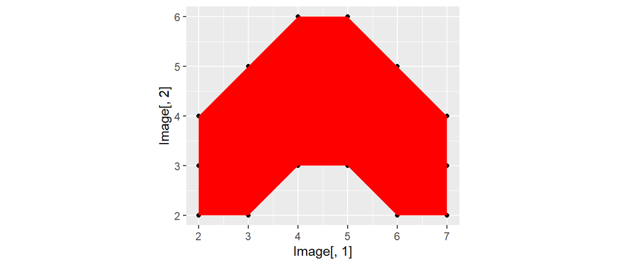

```r
Image <- cbind((x), (y))

qplot(Image[,1], Image[,2] ) + geom_polygon(fill = "red") + coord_fixed()
```

## Матрицы позволяют преобразовывать системы векторов

Вращающая матрица \[ \textbf{Rot} = \begin{pmatrix} \cos\phi & -\sin \phi \\ \sin\phi & \cos\phi \end{pmatrix} \]

Поворот изображения на заданный угол

\[ \textbf{Y}_{rot} = \textbf{Rot} \times \textbf{Y} \]

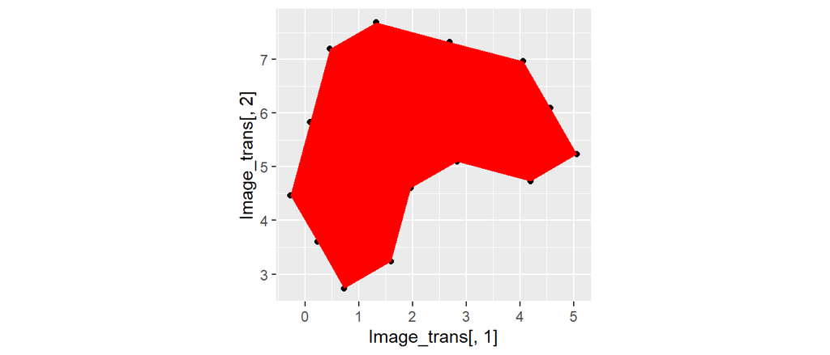

```r
phi <- 30  # Угол в градусах,
# на который надо повернуть объект

angle <- phi*pi/180 # Угол в радианах

# Вращающая матрица
Rot <- matrix(c(cos(angle), sin(angle),
                -sin(angle), cos(angle)), nrow = 2)


# Перобразованние исходной матрицы
# с помощью вращающей матрицы

Image_trans <-   t((Rot) %*% t(Image))


qplot(Image_trans[,1], Image_trans[,2] ) +
  geom_polygon(fill = "red") +
  coord_fixed()
```

## Матрицы позволяют преобразовывать системы векторов

Масштабирующая матрица \[ \textbf{Scale} = \begin{pmatrix} a & 0 \\ 0 & b \end{pmatrix} \]

\[ \textbf{Y}_{scaled} = \textbf{Scale} \times \textbf{Y} \]

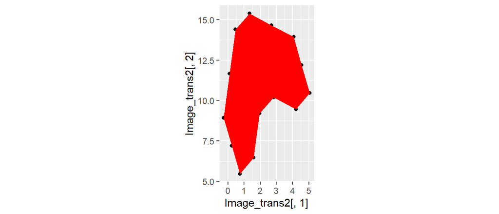

```r
Scale <- matrix(c(1, 0, 0, 2), nrow = 2)

Image_trans2 <-   t((Scale) %*% t(Image_trans))

qplot(Image_trans2[,1], Image_trans2[,2] ) +
  geom_polygon(fill = "red") +
  coord_fixed()
```

## Level 6: Корреляционные и ковариационные матрицы

## Ковариационная матрица

Во многих методах многомерной статистики применяется матрица ковариации.

Ковариация (согласованное отклонение от среднего):

\[ cov(X, Y) = \frac{1}{n - 1}\sum{(x_i - \bar{x})(y_i - \bar{y})} \]

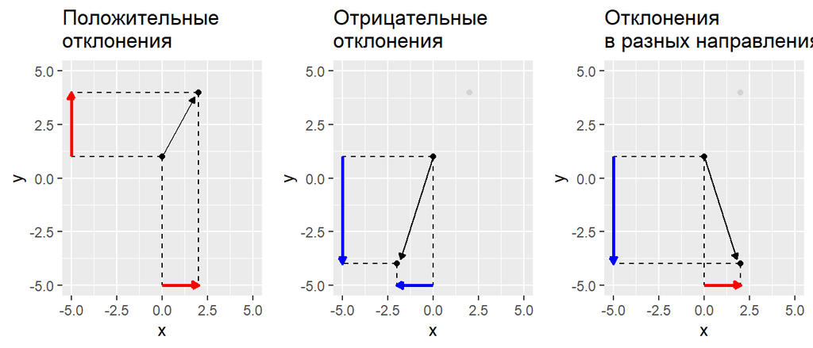

## Ковариационная матрица

\[ \textbf{S} = \frac{1}{n - 1} \textbf{Y}_{centered}'\textbf{Y}_{centered} \]

где \(\textbf{Y}_{centered}\) - центрированная матрица исходных значений

**Центрирование** - перемещение начала координат в точку с координатами, равными срдним значениям (центроид)

## Корреляционая матрица

То же самое, что ковариационная матрица, но только на основе стандартизованных исходных значений

\[ \textbf{R} = \frac{1}{n - 1} \textbf{Y}_{stand}'\textbf{Y}_{stand} \]

## Вычисление матрицы ковариации с помощью линейной алгебры

Исходная матрица

```r
M <- matrix(c(1,2,3,4,5,5,2,1,2,5,2,1,3,5,4,6,8,4,0,2), ncol = 4)
M
```

```
##      [,1] [,2] [,3] [,4]
## [1,]    1    5    2    6
## [2,]    2    2    1    8
## [3,]    3    1    3    4
## [4,]    4    2    5    0
## [5,]    5    5    4    2
```

Матрица центрированных значений

```r
Cent_M <- scale(M, center = TRUE, scale = FALSE)
Cent_M
```

```
##      [,1] [,2] [,3] [,4]
## [1,]   -2    2   -1    2
## [2,]   -1   -1   -2    4
## [3,]    0   -2    0    0
## [4,]    1   -1    2   -4
## [5,]    2    2    1   -2
## attr(,"scaled:center")
## [1] 3 3 3 4
```

## Вычисление матрицы ковариации с помощью линейной алгебры

### Задание:

Вычислите ковариационную матрицу с помощью методов линейной алгебры и сравните ее с матрицей, полученной с помощью функции `cov()`

## Вычисление матрицы ковариации с помощью линейной алгебры

### Решение:

```r
# Вычисление вручную
Cov_M <- (t(Cent_M) %*% Cent_M)/(nrow(M) - 1)
Cov_M
```

```
##      [,1] [,2] [,3] [,4]
## [1,]  2.5  0.0  2.0   -4
## [2,]  0.0  3.5  0.0    0
## [3,]  2.0  0.0  2.5   -5
## [4,] -4.0  0.0 -5.0   10
```

```r
cov(M) # Стандартная функция R
```

```
##      [,1] [,2] [,3] [,4]
## [1,]  2.5  0.0  2.0   -4
## [2,]  0.0  3.5  0.0    0
## [3,]  2.0  0.0  2.5   -5
## [4,] -4.0  0.0 -5.0   10
```

## Вычисление матрицы ковариации с помощью линейной алгебры

По главной диагонали ковариационной матрицы лежат квадраты стандартных отклонений каждого из векторов (колонок, признаков) исходной матрицы

```r
diag(Cov_M)
```

```
## [1]  2.5  3.5  2.5 10.0
```

Сравним

```r
apply(M, 2, FUN = function(x)sd(x)^2)
```

```
## [1]  2.5  3.5  2.5 10.0
```

## Вычисление матрицы корреляций с помощью линейной алгебры

Для вычисления матрицы корреляций необходимо стандартизировать значения в исходной матрице

```r
Stand_M <- scale(M, center = TRUE, scale = TRUE)
Stand_M
```

```
##        [,1]   [,2]   [,3]   [,4]
## [1,] -1.265  1.069 -0.632  0.632
## [2,] -0.632 -0.535 -1.265  1.265
## [3,]  0.000 -1.069  0.000  0.000
## [4,]  0.632 -0.535  1.265 -1.265
## [5,]  1.265  1.069  0.632 -0.632
## attr(,"scaled:center")
## [1] 3 3 3 4
## attr(,"scaled:scale")
## [1] 1.58 1.87 1.58 3.16
```

```r
# Вычисление вручную
Cor_M <- (t(Stand_M) %*% Stand_M)/(nrow(M) - 1)
Cor_M
```

```
##      [,1] [,2] [,3] [,4]
## [1,]  1.0    0  0.8 -0.8
## [2,]  0.0    1  0.0  0.0
## [3,]  0.8    0  1.0 -1.0
## [4,] -0.8    0 -1.0  1.0
```

```r
cor(M) # Стандартная функция R
```

```
##      [,1] [,2] [,3] [,4]
## [1,]  1.0    0  0.8 -0.8
## [2,]  0.0    1  0.0  0.0
## [3,]  0.8    0  1.0 -1.0
## [4,] -0.8    0 -1.0  1.0
```

## Зачем нужна ковариационная матрица?

В ковариационной матрице содержится вся информация о варьировании признаков и о их взаимосвязи

Свойства этой матрицы позволяют раскладывать изменчивость на отдельные составляющие.

## Level 7: Обращение (инверсия) матриц

## Обращение (инверсия) матриц

В линейной алгебре нет процедуры деления. Вместо нее используют обращение матриц.

\[ \textbf{X}^{-1}\textbf{X} = \textbf{I} \]

Обратить можно только такую матрицу, у которой определитель не равен нулю \[|\textbf{X}| \ne 0\]

Матрицы, у которых определитель \(|\textbf{X}| = 0\) называются *сингулярными* матрицами они не могут быть инвертированы.

**Важно!**: Только квадратные матрицы имеют обратную матрицу.

Для квадратных матриц справедливо \(\textbf{X} \textbf{X}^{-1} = \textbf{X}^{-1} \textbf{X}\)

**Важное свойство**: Если квадратная матрица состоит из ортогональных векторов (ортогональная матрица), то \(\textbf{X}' = \textbf{X}^{-1}\)

## Вычисление обратной матрицы в среде R

Создадим матрицу

```
##      [,1] [,2] [,3]
## [1,]    1    2    3
## [2,]    4    5    6
## [3,]    7    8   10
```

Ее определитель

```r
det(X)
```

```
## [1] -3
```

## Вычисление обратной матрицы в среде R

Обратная матрица

```r
solve(X)
```

```
##        [,1]  [,2] [,3]
## [1,] -0.667 -1.33    1
## [2,] -0.667  3.67   -2
## [3,]  1.000 -2.00    1
```

По определению \(\textbf{X}^{-1}\textbf{X} = \textbf{I}\)

```r
round(solve(X) %*% X )
```

```
##      [,1] [,2] [,3]
## [1,]    1    0    0
## [2,]    0    1    0
## [3,]    0    0    1
```

## Level 8: Собственные значения, собственные векторы и главные оси

## Постановка проблемы

Одним из подходов к снижению размерности многомерного пространства признаков является представление исходной матрицы (\(\textbf{Y}\)) в **ортогональной форме**.

В исходной матрице большинство векторов неортогональны, то есть взаимозависимые (между ними существует корреляция).

Задача сводится к тому, чтобы заменить исходные векторы (признаки) новыми комплексными признаками, которые были бы взаимно независимыми, то есть ортогональными.

Каждый из этих векторов несет определнную часть информации об исходной системе векторов (берет на себя некоторую долю общей дисперсии).

## Собственные числа и собственные векторы

Связь между векторами в исходной матрице \(\textbf{Y}\) выражается через ковариационную матрицу \(\textbf{S}\) или корреляционную матрицу (\(\textbf {R}\)).

\(\textbf{S}\) - это квадратная симметричная матрица.

Задача сводится к тому, чтобы из матрицы \(\textbf{S}\)

получить матрицу

\[ \bf{\Lambda} = \begin{pmatrix} \lambda_{1} & 0 & \cdots & 0 \\ 0 & \lambda_{2} & \cdots & 0 \\ \vdots & \vdots & \ddots & \vdots \\ 0 & 0 & \cdots & \lambda_{p} \end{pmatrix} \]

По главной диагонали лежат так называемые **собственные значения**, все остальные значения равны нулю

Каждому собственному значению \(\lambda_i\) ставится в соответствие так называемый **собственный вектор** \(\textbf{u}_i\). Совокупность собственных векторов формирует матрицу собственных векторов \(\textbf{U}\)

Собственные векторы перпендикулярны друг другу (ортогональны).

## Связь между матрицами

Связь между матрицей \(\bf{\Lambda}\) и \(\textbf{S}\) выражается следующим уравнением

\[ \textbf{S}\textbf{U} = \textbf{U}\bf{\Lambda} \]

где  
\(\textbf{S}\) - матрица ковариации  
\(\textbf{U}\) - матрица собственных векторов  
\(\bf{\Lambda}\) - Диагональная матрица собственных значений

Тогда

\[ \textbf{S} = \textbf{U}\bf{\Lambda}\textbf{U}^{-1} \] Это позволяет раскладывать матрицу \(\textbf{S}\) на составляющие (eigenvalues decomposition).

Каждое собственное число в матрице \(\bf{\Lambda}\) (и соответствующий ему ветор из матрицы \(\textbf{U}\)) несет часть информации об исходной матрице \(\textbf{S}\).

Разложение матрицы позволяет использовать не всю информацию, а только ее наиболее важную часть.

## Геомтерическая интерпретация: Главные оси

Во многих многомерных методах требуется найти оси максимального варьирования

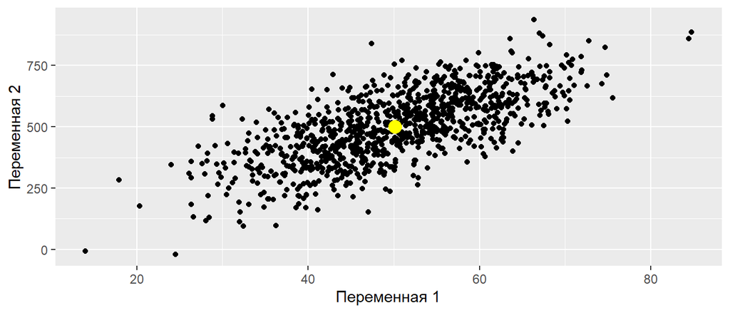

```r
set.seed(123456789)

x <- rnorm(1000, 50, 10)
y <- 10 * x + rnorm(1000, 0, 100)
XY <-data.frame(x = x, y = y)
qplot(XY$x, XY$y) + labs(x = "Переменная 1", y = "Переменная 2") +
  geom_point(aes(x = mean(x), y = mean(y)), size = 4, color = "yellow")
```

## Геомтерическая интерпретация: Главные оси

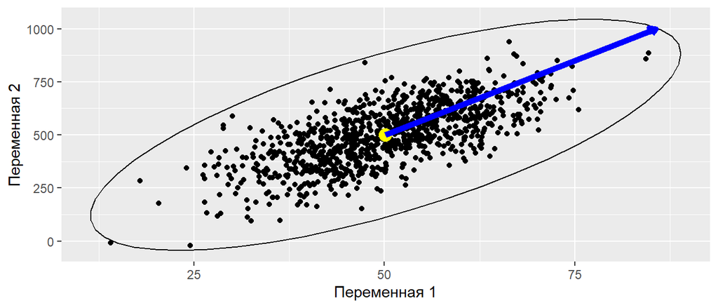

```r
qplot(XY$x, XY$y) + labs(x = "Переменная 1", y = "Переменная 2") +
  geom_point(aes(x = mean(x), y = mean(y)), size = 4, color = "yellow") +
  stat_ellipse(type = "norm", level = 0.9993) +
  geom_segment(aes(x = mean(x), y = mean(y), xend = (mean(x) + 3.5*sd(x)), yend = (mean(y) + 3.5*sd(y))),  arrow = ar, color = "blue", size = 2)
```

Главные оси проходят через центроид (\(\mathbf{\mu} = [\mu_1, \mu_2 \dots \mu_n]\)) и некоторую точку на поверхности эллипса (\(\mathbf{y} = [y_1, y_2 \dots y_n]\)).

Задача: найти такую точку.

Эта точка соответствует максимальной длине вектора, соединяющего центроид и данную точку.

## Нормализуем векторы

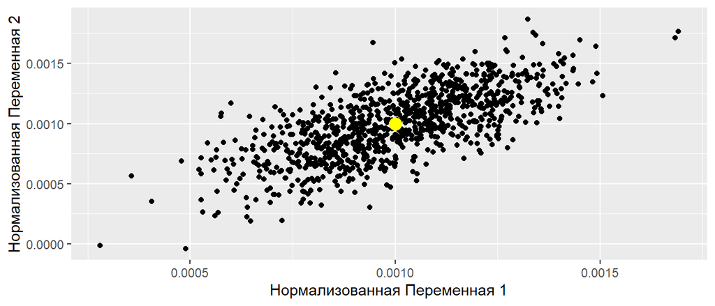

```r
x_norm <- XY$x/sqrt(sum(XY$x)^2)
y_norm <- XY$y/sqrt(sum(XY$y)^2)


XY_norm <- data.frame(x = x_norm, y = y_norm)


ggplot(XY_norm , aes(x = x, y = y)) + geom_point() +
  geom_point(aes(x = mean(x), y = mean(y)), size = 4, color = "yellow")  +
  labs(x = "Нормализованная Переменная 1", y = "Нормализованная Переменная 2")
```

## Центрируем нормализованные векторы

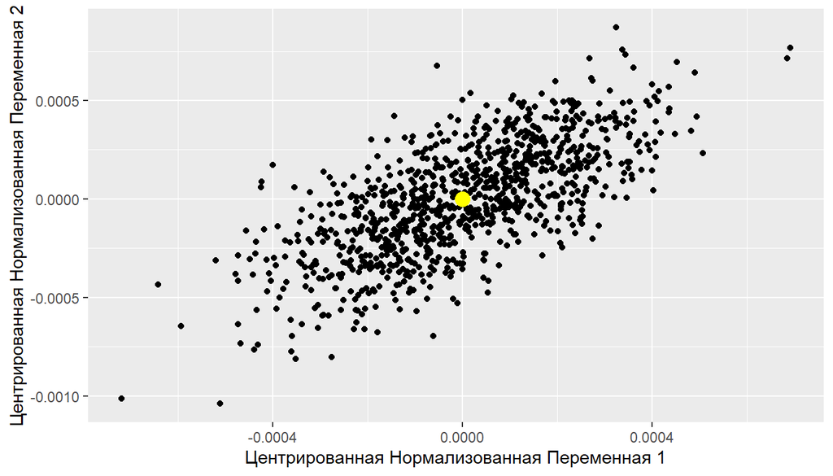

```r
XY_norm_cent <- as.data.frame(scale(XY_norm, center = TRUE, scale = FALSE))

ggplot(XY_norm_cent , aes(x = x, y = y)) + geom_point() +
  geom_point(aes(x = mean(x), y = mean(y)), size = 4, color = "yellow") +
  labs(x = "Центрированная Нормализованная Переменная 1", y = "Центрированная Нормализованная Переменная 2")
```

## Находим ковариационную матрицу

```r
mXY_norm_cent <- as.matrix(XY_norm_cent)

Sxy_norm_cent <- t(mXY_norm_cent) %*% mXY_norm_cent /(nrow(mXY_norm_cent) - 1)

Sxy_norm_cent
```

```
##              x            y
## x 0.0000000409 0.0000000402
## y 0.0000000402 0.0000000806
```

## Находим собственные числа и собственные векторы

```r
eig <- eigen(Sxy_norm_cent) # Стандартная функция R для извлечения собственных чисел и собственных векторов

Lambda <- eig$values # Собственные числа

Lambda
```

```
## [1] 0.0000001056 0.0000000159
```

```r
U <- eig$vectors # Собственные векторы

U
```

```
##       [,1]   [,2]
## [1,] 0.528 -0.849
## [2,] 0.849  0.528
```

## Стандартизованные собственные векторы

Собственные векторы безразмерны.

Но их можно масштабировать, выразив в величинах стандартных отклонений \(\textbf{U}_{scaled} = \textbf{U}\bf{\Lambda}^{1/2}\)

Почему так?

\(\textbf{U}_{scaled} \textbf{U}'_{scaled} = [\textbf{U}\bf{\Lambda}^{1/2}][\textbf{U}\bf{\Lambda}^{1/2}]' = \textbf{U}\bf{\Lambda}\textbf{U}' = \textbf{U}\bf{\Lambda}\textbf{U}^{-1} = \textbf{S}\)

Ковариационная матрица для стандартизованной матрицы собственных векторов совпадает с ковариационной матрицей исходной матрицы

```r
U_scaled <- U %*% sqrt(diag(Lambda)) #

(U %*% sqrt(diag(Lambda))) %*% t(U %*% sqrt(diag(Lambda)))
```

```
##              [,1]         [,2]
## [1,] 0.0000000409 0.0000000402
## [2,] 0.0000000402 0.0000000806
```

## Рисуем собственные векторы

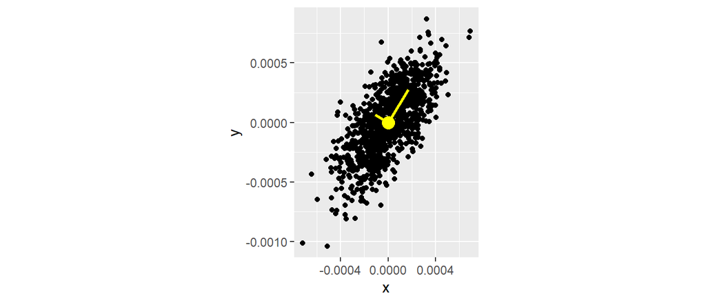

```r
PC1 <- data.frame(x = c(mean(XY_norm_cent$x), U_scaled[1, 1]),
                  y = c(mean(XY_norm_cent$y),  U_scaled[2,1]))

PC2 <- data.frame(x = c(mean(XY_norm_cent$x),  U_scaled[1, 2]),
                  y = c(mean(XY_norm_cent$y),  U_scaled[2,2]))

ggplot(XY_norm_cent, aes(x = x, y = y)) + geom_point() +
  geom_point(aes(x = mean(x), y = mean(y)), size = 4, color = "yellow") +
  geom_line(data = PC1, aes(x = x, y = y), color = "yellow", size = 1)  +
  geom_line(data = PC2, aes(x = x, y = y), color = "yellow", size = 1) +
  coord_equal()
```

## Рисуем главные оси

Матрица собственных векторов

```r
U
```

```
##       [,1]   [,2]
## [1,] 0.528 -0.849
## [2,] 0.849  0.528
```

```r
Pl_main_axis <- ggplot(XY_norm_cent, aes(x = x, y = y)) +
  geom_point() +
  geom_point(aes(x = mean(x), y = mean(y)),
             size = 4, color = "yellow") +
  geom_line(data = PC1, aes(x = x, y = y),
            color = "yellow", size = 1.5)  +
  geom_line(data = PC2, aes(x = x, y = y),
            color = "yellow", size = 1.5) +
  coord_equal() +
  geom_abline(slope = tan(acos(U[1,1])),
              color = "blue") +
  geom_abline(slope = tan(acos(U[1,1]) +
                            acos(U[2,1]) + acos(U[2,2])),
              color = "blue")
```

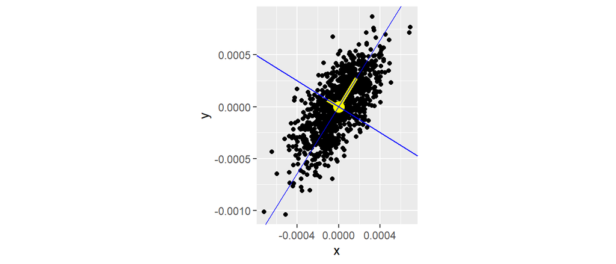

```r
Pl_main_axis
```

Для удобства восприятия лучше повернуть систему координат так, чтобы ось максимального варьирования была расположена горизонтально.

## Вращение осей

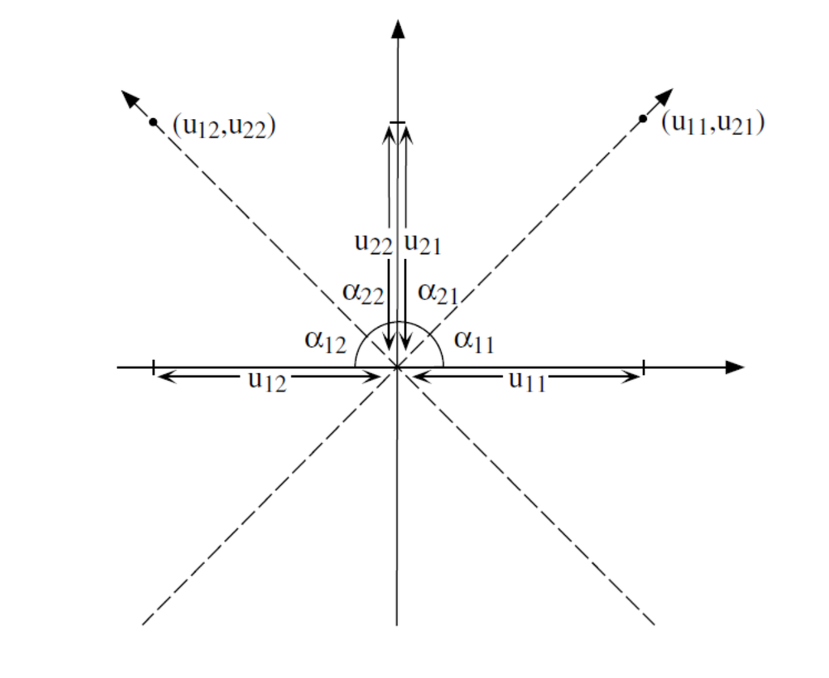

Из Legendre & Legendre, 2012

\[ \cos(\alpha_{11}) = u_{11}\\ \cos(\alpha_{21}) = u_{21}\\ \cos(\alpha_{12}) = u_{12}\\ \cos(\alpha_{22}) = u_{22} \]

Вращающая матрица

```r
angle <- -1 * acos(U[1,1]) #Отрицательный угол, так как
# поворачиваем оси по часовой стрелке

Rot <- matrix(c(cos(angle), sin(angle),
                -sin(angle), cos(angle)), nrow = 2)
Rot
```

```
##        [,1]  [,2]
## [1,]  0.528 0.849
## [2,] -0.849 0.528
```

## Вращение осей

Новые оси

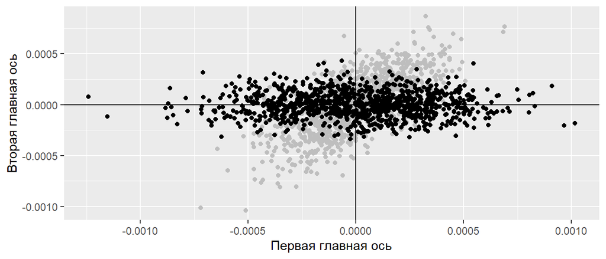

```r
XY_norm_cent_rot <- as.data.frame(t(Rot %*% t(mXY_norm_cent)))

Pl_main_axis_rotated <- ggplot(XY_norm_cent, aes(x = x, y = y)) +
  geom_point(color = "gray") +
  geom_point(data = XY_norm_cent_rot, aes(x = V1, y = V2)) +
  labs(x = "Первая главная ось", y = "Вторая главная ось") +
  geom_hline(yintercept = 0) +
  geom_vline(xintercept = 0)

Pl_main_axis_rotated
```

## Вращение осей

Новые и старые оси

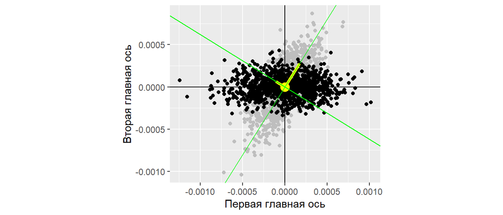

```r
Pl_main_axis_rotated +
  geom_point(aes(x = mean(x), y = mean(y)),
             size = 4, color = "yellow") +
  geom_line(data = PC1, aes(x = x, y = y),
            color = "yellow", size = 1.5)  +
  geom_line(data = PC2, aes(x = x, y = y),
            color = "yellow", size = 1.5) +
  coord_equal() +
  geom_abline(slope = tan(acos(U[1,1])),
              color = "green") +
  geom_abline(slope = tan(acos(U[1,1]) +
                            acos(U[2,1]) + acos(U[2,2])),
              color = "green")
```

## Главное о снижении размерности

1.Информацию об исходной матрице \(\textbf{Y}\) можно сконцентрировать в ковариационной матрице

\[ \textbf{S} = \frac{1}{n - 1} \textbf{Y}_{centered}'\textbf{Y}_{centered} \]

2.Матрицу ковариации можно разложить на собственные числа и собственные векторы

\[ \textbf{S} = \textbf{U}\bf{\Lambda}\textbf{U}^{-1} \]

3.Собственные векторы ортогональны и позволяют созадать новую систему координат. Новые оси (главные оси) “опираются” на собственные векторы.

4.Каждая ось в новой системе координат несет некоторую часть информации об исходной системе координат. Информативность осей определяется величиной собственных чисел.

5.Вместо многомерной системы координат (n осей) мы можем использовать всего несколько (например, две) ниаболее информативные главные оси.